# Assess quanTIseq results calculated with tumor purity thresholded data

SJ Spielman for CCDL

2023

This notebook was written as part of manuscript revisions. Here, we explore how `quanTIseq`-related results might change if only tumors at a certain level of known tumor purity (`tumor_fraction` metadata variable) are considered. Only stranded RNA data is considered here, as in the manuscript.

The associated issue for this exploration is here: https://github.com/AlexsLemonade/OpenPBTA-analysis/issues/1628

## Set directories and files

```r
root_dir <- rprojroot::find_root(rprojroot::has_dir(".git"))
data_dir <- file.path(root_dir, "data")
palette_file <- file.path(root_dir, "figures", "palettes", "broad_histology_cancer_group_palette.tsv")
metadata_file <- file.path(data_dir, "pbta-histologies.tsv")
quantiseq_file <- file.path("results", "quantiseq_deconv-output-thresholded.rds")
```

Read in and prep data:

```r
quantiseq_raw_df <- read_rds(quantiseq_file)
metadata_df <- read_tsv(metadata_file, guess_max = 10000)
palette_df <- read_tsv(palette_file)
# These are the groups we highlight in the manuscript
cancer_groups_of_interest <- c("Pilocytic astrocytoma",
                               "Diffuse midline glioma",
                               "Craniopharyngioma",
                               "Ganglioglioma",
                               "Ependymoma",
                               "Medulloblastoma",
                               "Schwannoma",
                               "Neurofibroma Plexiform",
                               "Other embryonal tumor",
                               "Atypical Teratoid Rhabdoid Tumor",
                               "Meningioma",
                               "Dysembryoplastic neuroepithelial tumor")

# Combine with cancer group and palette info
quantiseq_df <- quantiseq_raw_df %>%
  select(-library, -method) %>%
  rename(Kids_First_Biospecimen_ID = sample) %>%
  inner_join(
    select(
      metadata_df,
      cancer_group,
      Kids_First_Biospecimen_ID
    )
  ) %>%
  inner_join(
    select(
      palette_df,
      cancer_group,
      cancer_group_display,
      cancer_group_hex
    )
  ) %>%
  select(-cancer_group) %>%
  # Filter to relevant rows as in MS figure
  filter(cell_type != "uncharacterized cell") %>%
  filter(cancer_group_display %in% cancer_groups_of_interest)
```

## Re-generate plots

Here we will re-make the two `quanTIseq` plots:

- First the immune fractions across cancer groups for each cell type
- Second the CD8/CD4 ratio for molecular subtypes of interest. Note that there are *far fewer subtypes* that get plotted here due to the threshold filtering!

### Immune fractions across cancer groups

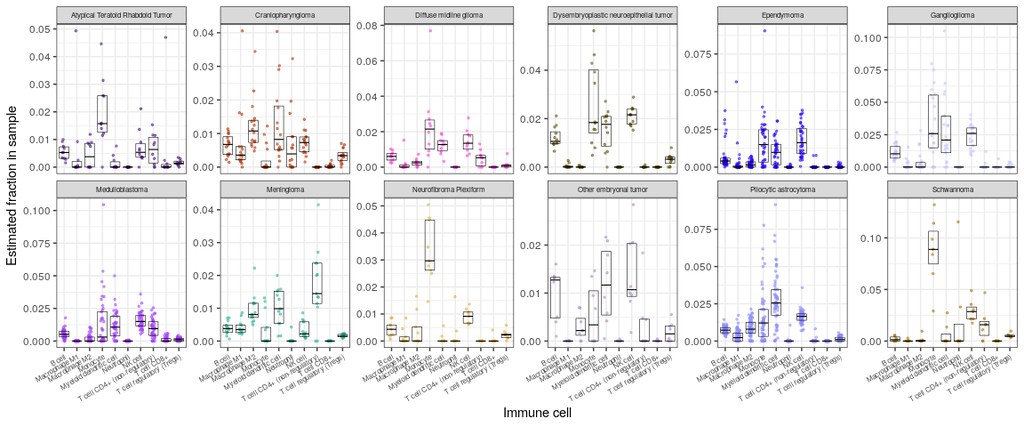

```r
# plot by cancer group groups of interest
ggplot(quantiseq_df) +
  aes(x = cell_type,
      y = score,
      color = cancer_group_hex) +
  geom_jitter(width = 0.15, size = 0.6, alpha = 0.5) +
  geom_boxplot(outlier.size = 0,
               size = 0.2,
               color = "black",
               alpha = 0,
               # remove whiskers
               coef = 0) +
  facet_wrap(~cancer_group_display, nrow = 2, scales = "free_y") +
  scale_color_identity() +
  labs(
    x = "Immune cell",
    y = "Estimated fraction in sample"
  ) +
  theme(
    axis.text.x = element_text(angle = 30, hjust = 1, size = 6),
    strip.text = element_text(size = 6)
  )
```

### CD8/CD4 ratios

```r
# Find molecular subtypes, and their order, to include in this panel
broad_histology_order <- c("Tumor of sellar region", "Ependymal tumor", "Embryonal tumor", "High-grade glioma")

subtype_order <- palette_df %>%
  inner_join(
    select(metadata_df,
           broad_histology,
           molecular_subtype)
  ) %>%
  select(broad_histology_display, molecular_subtype) %>%
  # keep only relevant histologies
  filter(broad_histology_display %in% broad_histology_order) %>%
  # remove NA and unclassified subtypes
  filter(!is.na(molecular_subtype),
         !str_detect(molecular_subtype, "To be classified")) %>%
  # Keep only combinations with N>=3
  count(broad_histology_display, molecular_subtype) %>%
  filter(n >= 3) %>%
  # Factor/arrange broad_histology_display to obtain the final molecular_subtype order
  mutate(broad_histology_display = fct_relevel(broad_histology_display, broad_histology_order)) %>%
  arrange(broad_histology_display) %>%
  pull(molecular_subtype)
# Calculate cd8+/cd4+ ratio for all subtypes, join with subtype/histology, and set up factors
ratio_df <- quantiseq_df %>%
  spread(cell_type, score) %>%
  mutate(cd8_cd4_ratio = `T cell CD8+` / `T cell CD4+ (non-regulatory)`)  %>%
  select(Kids_First_Biospecimen_ID, cd8_cd4_ratio) %>%
  # Keep only the known ratios
  filter(!(is.infinite(cd8_cd4_ratio)),
         !(is.nan(cd8_cd4_ratio))) %>%
  # Join with subtypes
   inner_join(
    select(metadata_df,
           Kids_First_Biospecimen_ID,
           broad_histology,
           molecular_subtype)
  ) %>%
  # Filter to subtype_order set up for Figure S6E
  filter(molecular_subtype %in% subtype_order)
```

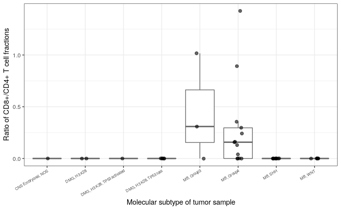

```r
# Plot
ggplot(ratio_df) +
  aes(x = molecular_subtype,
      y = cd8_cd4_ratio) +
  # remove outliers
  geom_boxplot(outlier.shape = NA, color = "grey40", size = 0.5) +
  geom_jitter(width = 0.1, size = 2, alpha = 0.6) +
  labs(x = "Molecular subtype of tumor sample",
       y = "Ratio of CD8+/CD4+ T cell fractions") +
  theme(axis.text.x = element_text(hjust = 1,
                                   angle = 30,
                                   size = 6))
```

Now, we will re-assess specific results we report in the manuscript. Specifically, these are the parts of the manuscript sentences below that reference either Figure 5C or Figure S6F.

### Result 1

https://github.com/AlexsLemonade/OpenPBTA-manuscript/blob/b0fdf6f24fe9c021f22e8b7da348708f68877ee5/content/03.results.md?plain=1#L277-L278

> Schwannomas and neurofibromas, which have a documented inflammatory immune microenvironment of T and B lymphocytes as well as tumor-associated macrophages (TAMs), are driven by upregulation of cytokines such as IFN$\gamma$, IL-1, and IL-6, and TNF$\alpha$ [@doi:10.1093/noajnl/vdaa023]. Indeed, we observed significant upregulation of these cytokines in GSVA hallmark pathways (Bonferroni-corrected p < 0.05) (**Figure {@fig:Fig5}B**) and found immune cell types dominated by monocytes in these tumors (**Figure {@fig:Fig5}C**).

The first plot above recapitulates the result that monocytes are dominant in schwannomas and neurofibromas. The thresholded results are consistent.

### Result 2

https://github.com/AlexsLemonade/OpenPBTA-manuscript/blob/b0fdf6f24fe9c021f22e8b7da348708f68877ee5/content/03.results.md?plain=1#L282

> Although CD8+ T-cell infiltration across all cancer groups was quite low (**Figure {@fig:Fig5}C**), we observed some signal in specific cancer molecular subtypes (Groups 3 and 4 medulloblastoma) as well as outlier tumors (BRAF-driven LGG, BRAF-driven and wildtype ganglioglioma, and CNS embryonal NOS; **Figure {@fig:S6}E**)

The first plot shows that CD8+ T-cell infiltration across all cancer groups remains quite low. The second plot shows the MB 3/4 signal, but there are no longer any outliers. The thresholded results are consistent, and differences may be explained by sample size/power.

### Result 3

https://github.com/AlexsLemonade/OpenPBTA-manuscript/blob/b0fdf6f24fe9c021f22e8b7da348708f68877ee5/content/03.results.md?plain=1#L283

> Surprisingly, the classically immunologically-cold HGG and DMG tumors [@doi:10.1186/s40478-018-0553-x; @doi:10.1093/brain/awab155] contained higher overall fractions of immune cells, where monocytes, dendritic cells, and NK cells were the most prevalent (**Figure {@fig:Fig5}C**).

The first plot shows that for DMG, overall fractions fall in ranges that are consistent with other cancer groups, so “higher overall fractions” are no longer the case. This difference may be a consequence of reduced sample size overall for this re-analysis. DMGs are dominated by monocytes, dendritic cells, and NK cells, which is consistent with previous results.

However, as we did not actually plot other HGG groups here, e may wish to revise this statement to focus more on the panels that are actually in the plot more generally.

### Result 4

https://github.com/AlexsLemonade/OpenPBTA-manuscript/blob/b0fdf6f24fe9c021f22e8b7da348708f68877ee5/content/03.results.md?plain=1#L292

> While adamantinomatous craniopharyngiomas and Group 3 and Group 4 medulloblastomas had the highest CD8+ to CD4+ T cell ratios (**Figure {@fig:S6}F**), very few tumors had ratios greater than 1, highlighting an urgent need to identify novel therapeutics for these immunologically-cold pediatric brain tumors with poor prognosis.

As noted, the second plot itself has fewer subtypes, which is expected with a filtered dataset. Of note, the `CRANIO, ADAM` molecular subtype is no longer present. We again see that MB groups 3 and 4 have higher values with other molecular subtypes around 0, which is consistent with the original results.

## Conclusions

Overall, `quanTIseq` results are broadly consistent after thresholding.